# Project Business Statistics: E-news Express

# Observations from Univariate Analysis:

#### Balanced groups and pages:

Group and landing_page are evenly split (50/50), so the experiment was well designed.

#### Balanced language preference:

Roughly equal number of users across Spanish, French, and English — this will help ensure fairness when comparing across languages later.

#### Conversion Rate is slightly skewed:

More users said “yes” to being converted (54%) than “no” (46%). This could be good news for the business — but needs hypothesis testing.

#### No clear visual class imbalance:

This supports fair hypothesis testing.

### Mode

```python
df['time_spent_on_the_page'].mode()
```

```
0    0.40
1    3.88
2    4.75
3    5.86
4    6.04
5    7.16
Name: time_spent_on_the_page, dtype: float64
```

#### The most frequent values for time_spent_on_the_page aren’t tightly clustered — they’re spread across the range.

This suggests the user behavior isn’t concentrated around a single typical time. Instead, users tend to fall into multiple different engagement levels (e.g., quick scanners vs. medium readers vs. deep readers).

It aligns with what we might expect in A/B testing — different users may behave differently based on the landing page or preferred language

```python
Q1 = df['time_spent_on_the_page'].quantile(0.25)
Q3 = df['time_spent_on_the_page'].quantile(0.75)
IQR = Q3 - Q1
lower_bound = Q1 - 1.5 * IQR
upper_bound = Q3 + 1.5 * IQR

print("Outliers below:", df[df['time_spent_on_the_page'] < lower_bound].shape[0])
print("Outliers above:", df[df['time_spent_on_the_page'] > upper_bound].shape[0])
```

```
Outliers below: 0
Outliers above: 0
```

#### Outlier Detection - Time Spent on the Page

Using the IQR method, we found:

- **Outliers below:** 0
- **Outliers above:** 0

This confirms that the data is clean, with no extreme low or high values affecting the distribution. The time spent by users is relatively consistent and normally spread.

# Bivariate Analysis

## Landing Page vs Time Spent on the Page

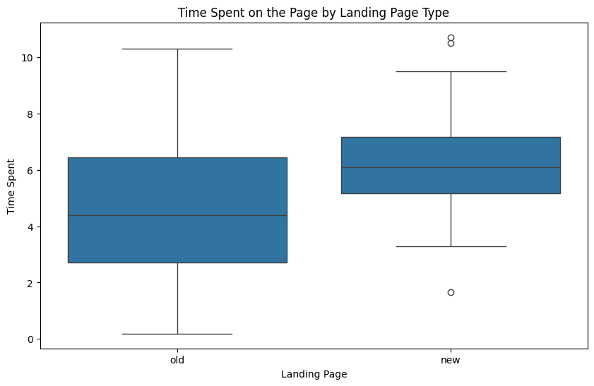

```python
plt.figure(figsize=(10,6))
sns.boxplot(data=df, x='landing_page', y='time_spent_on_the_page')
plt.title("Time Spent on the Page by Landing Page Type")
plt.xlabel("Landing Page")
plt.ylabel("Time Spent")
plt.show()
```

## Conversion Status vs Time Spent on the Page

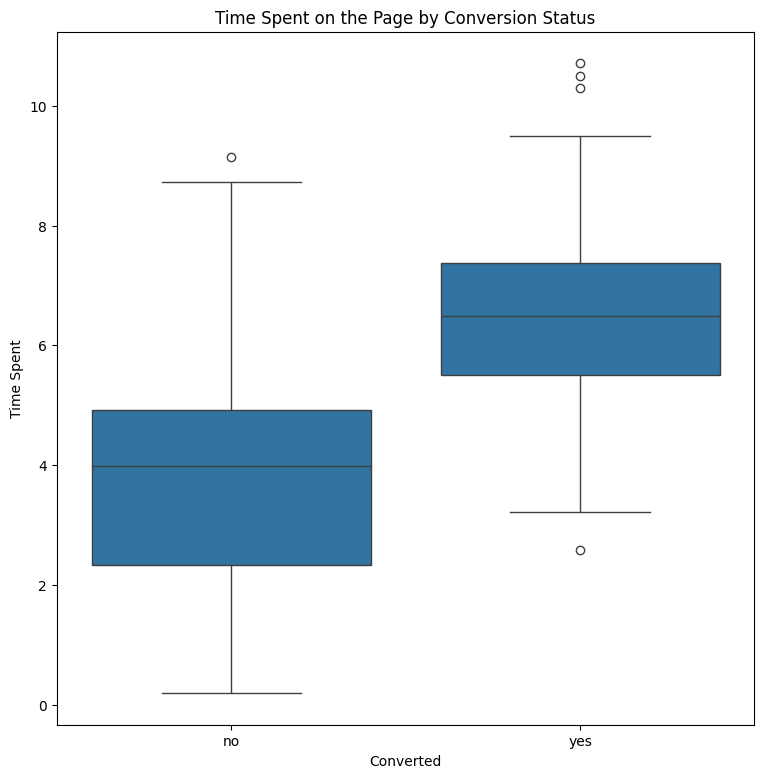

```python
plt.figure(figsize=(9, 9))
sns.boxplot(data=df, x='converted', y='time_spent_on_the_page')
plt.title("Time Spent on the Page by Conversion Status")
plt.xlabel("Converted")
plt.ylabel("Time Spent")
plt.show()
```

## Language Preferred vs Time Spent on the Page

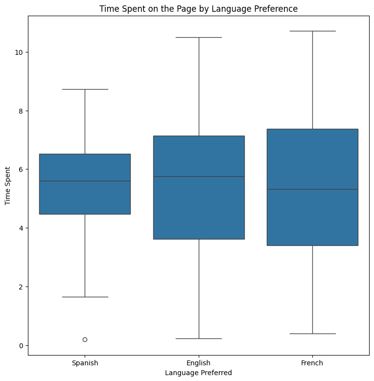

```python
plt.figure(figsize=(9, 9))
sns.boxplot(data=df, x='language_preferred', y='time_spent_on_the_page')
plt.title("Time Spent on the Page by Language Preference")
plt.xlabel("Language Preferred")
plt.ylabel("Time Spent")
plt.show()
```

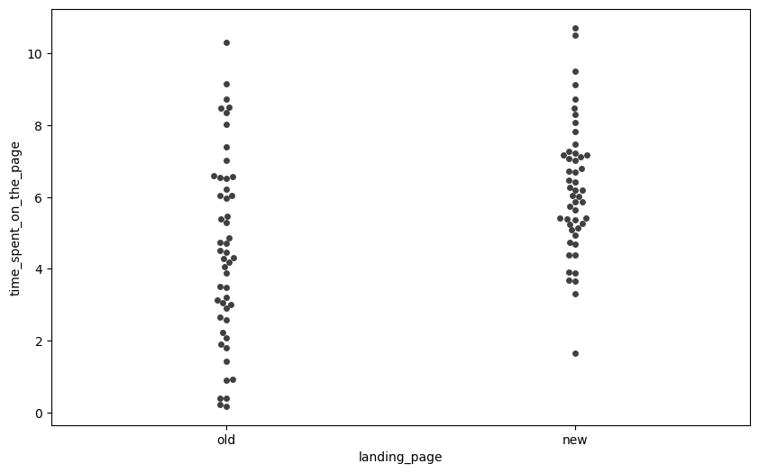

```python
plt.figure(figsize=(10,6))
sns.swarmplot(data=df, x='landing_page', y='time_spent_on_the_page', color=".25");
```

## Swarmplot overlay on Boxplot for clarity

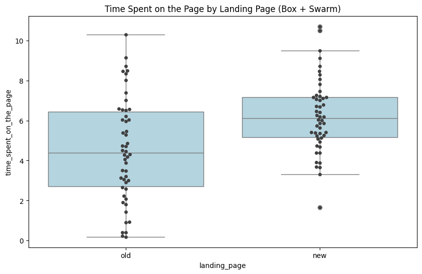

```python
plt.figure(figsize=(10, 6))
sns.boxplot(data=df, x='landing_page', y='time_spent_on_the_page', color='lightblue')
sns.swarmplot(data=df, x='landing_page', y='time_spent_on_the_page', color=".25")
plt.title("Time Spent on the Page by Landing Page (Box + Swarm)")
plt.show()
```

### What does this plot tell us?

#### Old Landing Page:

Median time spent looks slightly lower than the new page (~4.5 minutes).

Wider IQR (Interquartile Range): The box is longer, which means time spent varies more for the old page.

A very users are very close to being outliers: Around 0.5 lower end and 10 minutes upper end of the whiskers.

#### New Landing Page:

Median time spent is slightly higher (~6 minutes).

Tighter distribution: The middle 50% (the box) is more compact.

One clear outlier below: A user who spent very little time (~2 minutes).

Two clear outliers above. Users who spent more than 10 minutes.

#### Conclusions Bivariate Analysis: Time Spent vs. Landing Page

The box+swarm plot shows:

Median time spent is slightly higher for the **new landing page**.

The **old page** shows a wider variation in user behavior.

A few **high-value outliers** & one single *low-value outlier** for the new page.

This suggests the new page may encourage more consistent engagement, but further statistical testing is needed to confirm significance.

## 1. Do the users spend more time on the new landing page than the existing landing page?

### Perform Visual Analysis

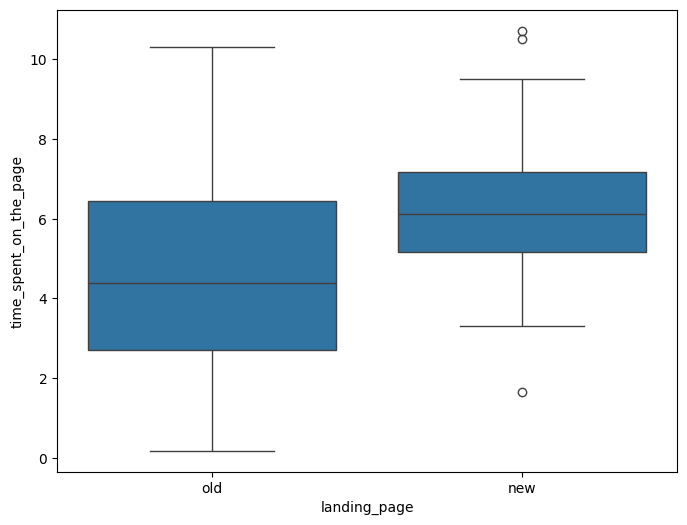

```python
# visual analysis of the time spent on the new page and the time spent on the old page
plt.figure(figsize=(8,6))
sns.boxplot(x = 'landing_page', y = 'time_spent_on_the_page', data = df)
plt.show()
```

### Observations:

### Step 1: Define the null and alternate hypotheses

### Hypothesis: Time Spent on New vs. Old Landing Page

**Business Question**:  
Do users spend more time on the new landing page than the old one?

**Null Hypothesis (H₀)**:  
The average time spent on the new page is less than or equal to that of the old page.

**Alternative Hypothesis (H₁)**:  
The average time spent on the new page is greater than that of the old page.

### Step 2: Select Appropriate test

This is a one-tailed test concerning the difference between two population means from two **independent** groups (users who saw the old landing page vs. those who saw the new one).

Since the population standard deviations are **unknown** and the sample sizes are relatively small, we use the:

**Independent Samples t-Test (One-Tailed)**

This test will help determine whether the **mean time spent on the new landing page** is **significantly greater** than that on the old page.

### Step 3: Decide the significance level

As given in the problem statement, we select α = 0.05.

### Step 4: Collect and prepare data

```python
# Create subsetted data frame for new landing page users
time_spent_new = df[df['landing_page'] == 'new']['time_spent_on_the_page']

# Create subsetted data frame for old landing page users
time_spent_old = df[df['landing_page'] == 'old']['time_spent_on_the_page']

# Print sample standard deviations
print('The sample standard deviation of the time spent on the new page is:', round(time_spent_new.std(), 2))
print('The sample standard deviation of the time spent on the old page is:', round(time_spent_old.std(), 2))
```

```
The sample standard deviation of the time spent on the new page is: 1.82
The sample standard deviation of the time spent on the old page is: 2.58
```

### Observation: Collect and Prepare Data

The sample standard deviation of time spent on the **new landing page** is **1.82**, and on the **old landing page** is **2.58**.

Since the difference in standard deviations is significant, we assume **unequal variances** for the two groups and set `equal_var = False` in our t-test.

### Step 5: Calculate the p-value

```python
# Import ttest_ind from scipy.stats
from scipy.stats import ttest_ind

# Perform one-tailed t-test (note: use equal_var based on step 4)
test_stat, p_value = ttest_ind(time_spent_new, time_spent_old, equal_var=False, alternative='greater')

print('The p-value is', p_value)
```

```
The p-value is 0.0001392381225166549
```

### Step 6: Compare the p-value with $\alpha$

The p-value is 0.000139

significance level α = 0.05

Since 0.000139 < 0.05 = True

We reject the null hypothesis.

### Step 7: Draw Inference

The p-value (0.00014) is significantly less than the significance level (α = 0.05), so we **reject the null hypothesis**.

**Conclusion:**  
There is statistically significant evidence to suggest that users **spend more time** on the **new landing page** compared to the old one.

**Business Insight:**  
The new landing page is more engaging and may be more effective at holding user attention. This supports moving forward with its broader rollout.

## 2. Is the conversion rate (the proportion of users who visit the landing page and get converted) for the new page greater than the conversion rate for the old page?

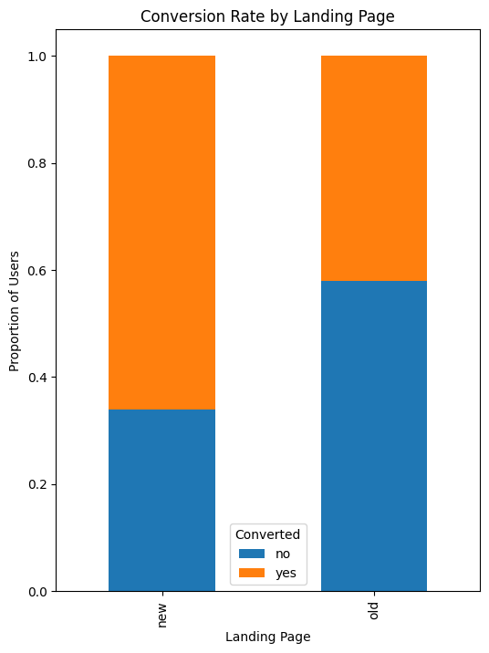

```python
# Code to visually compare the conversion rate for the new page vs old page

pd.crosstab(df['landing_page'], df['converted'], normalize='index').plot(kind="bar", figsize=(6, 8), stacked=True)

plt.title("Conversion Rate by Landing Page")
plt.xlabel("Landing Page")
plt.ylabel("Proportion of Users")
plt.legend(title="Converted")
plt.show()
```

### Visual Insight

A stacked bar chart comparing conversion outcomes shows that the **new landing page** has a **higher proportion (> 60%) of conversions** "yes" compared to the old page.

This suggests a potential improvement in performance for the new page, which will be formally tested using a two-proportion z-test.

### Step 1: Define the null and alternate hypotheses

$H_0:$ There is no improvement in conversion rate on the new page.

$H_a:$ The new page has a higher conversion rate than the old page.

### Step 2: Select the Appropriate Test

We are comparing the **conversion rates** (proportions of users who were converted) between **two independent groups** — users who saw the new landing page and those who saw the old one.

Since the outcome is **binary** (Yes or No), and we are comparing **two independent proportions**, the appropriate statistical test is:

**Two-Proportion Z-Test (One-Tailed)**

This will allow us to test if the **conversion rate for the new page** is **significantly greater** than that for the old page.

Assumptions are met?

Binomially distributed populations

Independent populations

Random sampling from the populations

When both mean (np) and n(1-p) are greater than or equal to 10.

The binomial distribution can be approximated by a normal distribution

### Step 3: Decide the Significance Level

As given in the problem statement, we select a **significance level of**

alpha = 0.05

This means we require at least 95% confidence to conclude that the new landing page performs better than the old one.

### Step 4: Collect and Prepare the Data

```python
# Calculate the number of converted users in the treatment group
new_converted = df[df['group'] == 'treatment']['converted'].value_counts()['yes']

# Calculate the number of converted users in the control group
old_converted = df[df['group'] == 'control']['converted'].value_counts()['yes']  # Completed

# Total number of users in each group
n_control = df['group'].value_counts()['control']
n_treatment = df['group'].value_counts()['treatment']

print('The numbers of users served the new and old pages are {0} and {1} respectively'.format(n_treatment, n_control))
```

```
The numbers of users served the new and old pages are 50 and 50 respectively
```

### Step 5: Calculate the P Value:

```python
# Import the required function for a two-proportion z-test
from statsmodels.stats.proportion import proportions_ztest

# Calculate the p-value for a one-tailed test (new > old)
test_stat, p_value = proportions_ztest([new_converted, old_converted], [n_treatment, n_control], alternative='larger')

print('The p-value is', p_value)

#Z-Statistic printed to see Standard Deviation
print('Z-statistic:', test_stat)
```

```
The p-value is 0.008026308204056278
Z-statistic: 2.4077170617153842
```

### Step 6 Compare P Value with Level of significance:

The Z-statistic is **2.41**, and the corresponding **p-value is 0.0080**, which is **less than the significance level (α = 0.05)**.

```python
# print the conclusion based on p-value
if p_value < 0.05:
    print(f'As the p-value {p_value} is less than the level of significance, we reject the null hypothesis.')
else:
    print(f'As the p-value {p_value} is greater than the level of significance, we fail to reject the null hypothesis.')
```

```
As the p-value 0.008026308204056278 is less than the level of significance, we reject the null hypothesis.
```

### Step 7 Conclusions:

**Conclusion:**

We reject the null hypothesis. There is statistically significant evidence to suggest that the **conversion rate for the new landing page** is **greater** than that for the old landing page.

**Business Recommendation:**  
The new landing page is performing better in terms of conversions. It is recommended that a wider rollout of the new page be considered to improve overall user engagement and success metrics.

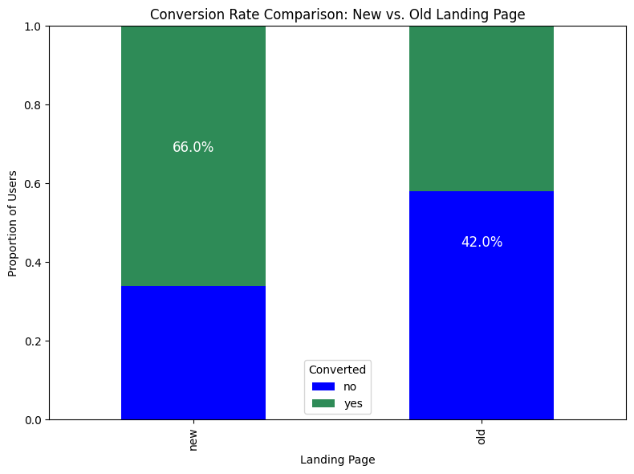

```python
import matplotlib.pyplot as plt

# Calculate conversion rates
conversion_rates = df.groupby('landing_page')['converted'].value_counts(normalize=True).unstack()

# Plot bar chart
conversion_rates.plot(kind='bar', stacked=True, figsize=(8,6), color=['blue', 'seagreen'])

# Add labels and title
plt.title("Conversion Rate Comparison: New vs. Old Landing Page")
plt.xlabel("Landing Page")
plt.ylabel("Proportion of Users")
plt.legend(title="Converted")
plt.ylim(0, 1)

# Add percentage labels
for idx, page in enumerate(conversion_rates.index):
    yes_rate = conversion_rates.loc[page, 'yes']
    plt.text(idx, yes_rate + 0.02, f"{yes_rate*100:.1f}%", ha='center', fontsize=12, color='white')

plt.tight_layout()
plt.show()
```

## 3. Is the conversion and preferred language are independent or related?

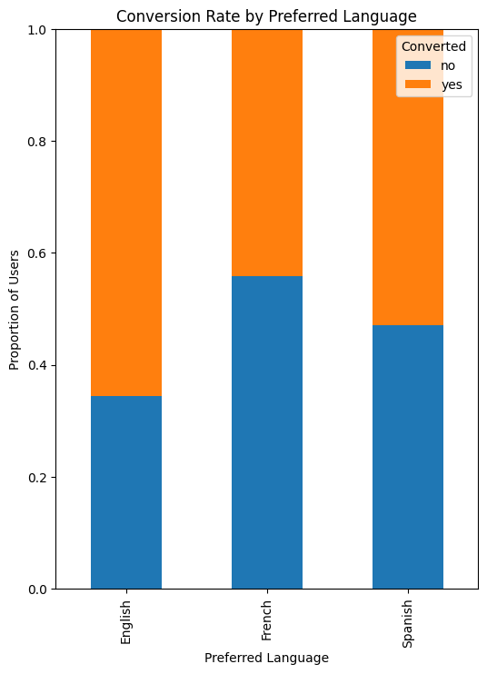

```python
# Visualize dependency between conversion status and preferred language
pd.crosstab(df['language_preferred'], df['converted'], normalize='index').plot(kind="bar", figsize=(6,8), stacked=True)

plt.title("Conversion Rate by Preferred Language")
plt.xlabel("Preferred Language")
plt.ylabel("Proportion of Users")
plt.legend(title="Converted")
plt.ylim(0, 1)
plt.show()
```

#### General Observations:

Each bar represents a preferred language group, broken down by the proportion of users who converted (yes) and did not convert (no).

```
English: Appears to have the highest conversion rate (more orange, less blue)

French: Shows the lowest conversion rate (more blue, less orange)

Spanish: Somewhere in between, leaning toward a low conversion rate
```

There are visible differences in conversion rates across the language groups, which suggests a possible dependency between converted and language_preferred.

BUT — to confirm whether these differences are statistically significant, we need to some tests.

### Step 1: Define the null and alternate hypotheses

$H_0:$ Conversion status is **independent** of preferred language

$H_a:$ Conversion status is **dependent** on preferred language

### Step 2: Select Appropriate test

#### Chi-Square Test of Independence

Used when:  
Categorical variables

```
        The expected value of the number of sample observations in each level of the variable is at least 5

        |Random sampling from the population
```

### Step 3: Decide the Significance Level

As given in the problem statement, we select a significance level of

alpha = 0.05

### Step 4 Collect and Prepare the data:

```python
# Create a contingency table showing the distribution of converted vs language_preferred
contingency_table = pd.crosstab(df['language_preferred'], df['converted'])

contingency_table
```

| converted language_preferred | no | yes |
| --- | --- | --- |
| English | 11 | 21 |
| French | 19 | 15 |
| Spanish | 16 | 18 |

#### Observations:

English users have the highest conversion rate → 21/32 = 66%  
French users have the lowest → 15/34 = 44% Spanish sits in between → 18/34 = 53%

These differences look interesting, but we need to test whether they’re statistically significant.

### Step 5 Calculate the p-value:

```python
# Import the chi2_contingency function from scipy.stats
from scipy.stats import chi2_contingency

# Run the Chi-Square test
chi2, p_value, dof, exp_freq = chi2_contingency(contingency_table)

print('The p-value is', p_value)
```

```
The p-value is 0.2129888748754345
```

### Step 6: Compare the p-value with alpha

p-value = 0.213  
Significance level alpha = 0.05

```python
# print the conclusion based on the p-value
if p_value < 0.05:
    print(f'As the p-value {p_value} is less than the level of significance, we reject the null hypothesis.')
else:
    print(f'As the p-value {p_value} is greater than the level of significance, we fail to reject the null hypothesis.')
```

```
As the p-value 0.2129888748754345 is greater than the level of significance, we fail to reject the null hypothesis.
```

### 7: Conclusion

We fail to reject the null hypothesis.

**Conclusion:**

```
There is no statistically significant relationship between a user's preferred language and whether or not they converted.
The data suggests that conversion status is independent of language preference.
```

**Business Recommendation:**

```
There is no need to tailor landing pages by language based on conversion data alone.
Resources can be focused on improving overall page effectiveness across all language segments.
```

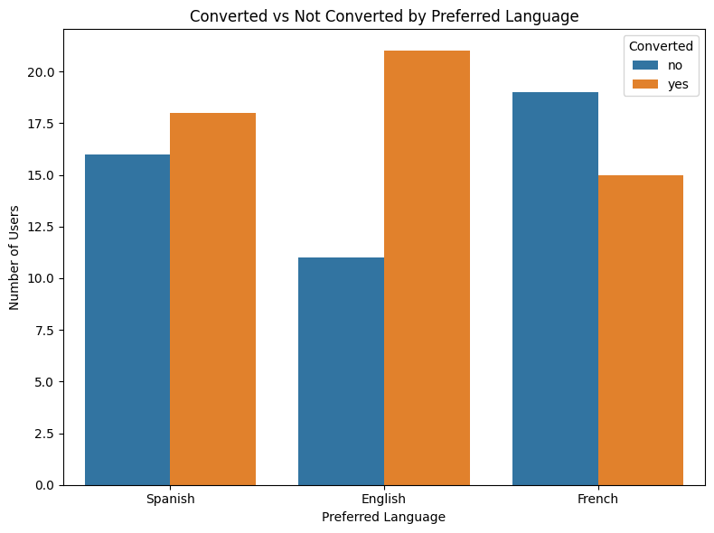

```python
# Countplot using seaborn
import seaborn as sns
plt.figure(figsize=(8,6))

sns.countplot(data=df, x='language_preferred', hue='converted')

plt.title("Converted vs Not Converted by Preferred Language")
plt.xlabel("Preferred Language")
plt.ylabel("Number of Users")
plt.legend(title="Converted")
plt.tight_layout()
plt.show()
```

### Visual Insight

The grouped bar chart shows some variation in conversion rates across languages — with English users converting more frequently than French or Spanish users.

However, this **visual difference is not statistically significant**, as confirmed by the chi-square test (p = 0.213). Therefore, we conclude that **conversion status and preferred language are independent**.

## 4. Is the time spent on the new page same for the different language users?

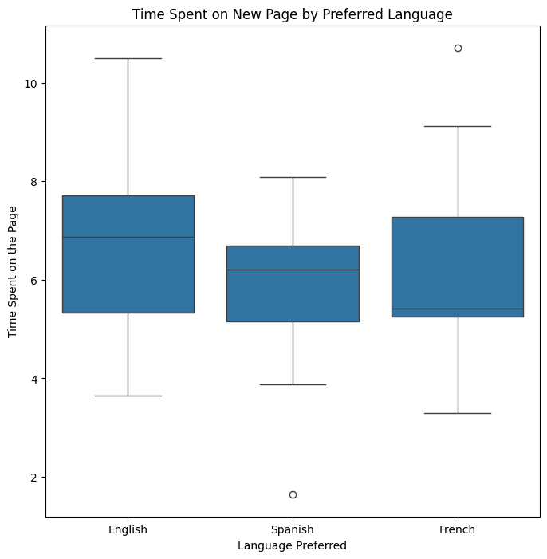

```python
# Create a new variable for users who got sent the new page
df_new = df[df['landing_page'] == 'new']

# Boxplot to compare time spent for each language
plt.figure(figsize=(8, 8))
sns.boxplot(x='language_preferred', y='time_spent_on_the_page', showmeans=False, data=df_new)
plt.title("Time Spent on New Page by Preferred Language")
plt.xlabel("Language Preferred")
plt.ylabel("Time Spent on the Page")
plt.show()
```

## Observation from Visuals

```
1.	English users appear to spend more time on average compared to French and Spanish users.

2.	Spanish users have the least variability (tightest box) and a low outlier, meaning most behavior is consistent.

3.	French users show more spread — perhaps some users skim, others dive deep, with one high outlier.
```

```python
# Calculate the mean time spent by language group
df_new.groupby('language_preferred')['time_spent_on_the_page'].mean()
```

```
language_preferred
English    6.663750
French     6.196471
Spanish    5.835294
Name: time_spent_on_the_page, dtype: float64
```

## Observation on the data results

These mean values support what we suspected from the boxplot.

There’s a clear ranking from English to French to Spanish.

But the difference between the highest and lowest is ~0.83 minutes — visually noticeable, but not necessarily statistically significant.

### Step 1: Define the null and alternate hypotheses

We are testing whether the **mean time spent on the new landing page** differs across **language groups**.

$H_0:$ Mean time spent is the same across all language groups

$H_a:$ At least one group has a mean time spent that is different

### Step 2: Select the Appropriate Test

We are comparing the **mean time spent on the new landing page** across **three independent language groups** (`English`, `French`, and `Spanish`).

The response variable (`time_spent_on_the_page`) is **continuous**, and the grouping variable (`language_preferred`) is **categorical with more than two groups**.

Therefore, the appropriate test is:

**One-Way ANOVA (Analysis of Variance)**

This test will help us determine whether there is a **statistically significant difference in mean time spent** across the different language groups.

We will proceed to check the assumptions of ANOVA (normality and equal variance) before conducting the test.

### Step 3: Decide the Significance Level

As specified in the question, we will use a significance level of:

alpha = 0.05

This means we require at least 95% confidence to conclude that **mean time spent differs across language groups**.

### Step 4: Check Assumptions

```python
from scipy.stats import shapiro

# Subsets of time spent by language group
english_time = df_new[df_new['language_preferred'] == 'English']['time_spent_on_the_page']
french_time = df_new[df_new['language_preferred'] == 'French']['time_spent_on_the_page']
spanish_time = df_new[df_new['language_preferred'] == 'Spanish']['time_spent_on_the_page']

# Shapiro-Wilk test for normality
print("English:", shapiro(english_time))

print("French:", shapiro(french_time))

print("Spanish:", shapiro(spanish_time))
```

```
English: ShapiroResult(statistic=0.9731259942054749, pvalue=0.8863451480865479)
French: ShapiroResult(statistic=0.9402673244476318, pvalue=0.3213688135147095)
Spanish: ShapiroResult(statistic=0.9072974920272827, pvalue=0.09006832540035248)
```

### Step 4a: Check Normality with Shapiro-Wilk Test

I applied the Shapiro-Wilk test to assess whether the `time_spent_on_the_page` variable is normally distributed within each language group.

| Language | p-value | Result |
| --- | --- | --- |
| English | 0.886 | Normal |
| French | 0.321 | Normal |
| Spanish | 0.090 | Normal |

All p-values are greater than 0.05, so the normality assumption for ANOVA is satisfied.

### Step 4b: Levene’s Test for Equal Variance

Step 4b is Levene’s test to check the second key ANOVA assumption: equal variances across groups.

```python
from scipy.stats import levene

# Levene’s test for homogeneity of variances
stat, p_value = levene(english_time, french_time, spanish_time)

print("Levene’s Test p-value:", p_value)
```

```
Levene’s Test p-value: 0.46711357711340173
```

### Step 4b: Check Equal Variance with Levene’s Test

Levene’s Test was used to assess the assumption of homogeneity of variances across language groups.

**p-value = 0.467**

Since the p-value is greater than 0.05, we conclude that the variances are equal. The assumption of equal variance is satisfied.

## Step 5: Calculate the p-value

```python
from scipy.stats import f_oneway

# Run the ANOVA test
f_stat, p_value = f_oneway(english_time, french_time, spanish_time)

print("ANOVA F-statistic:", round(f_stat, 4))
print("ANOVA p-value:", p_value)
```

```
ANOVA F-statistic: 0.8544
ANOVA p-value: 0.43204138694325955
```

### Step 6: Compare the p-value with $\alpha$

```python
# print the conclusion based on p-value
if p_value < 0.05:
    print(f'As the p-value {p_value} is less than the level of significance, we reject the null hypothesis.')
else:
    print(f'As the p-value {p_value} is greater than the level of significance, we fail to reject the null hypothesis.')
```

```
As the p-value 0.43204138694325955 is greater than the level of significance, we fail to reject the null hypothesis.
```

### Step 7: ANOVA Conclusion

**Conclusion:**  
There is **no statistically significant difference** in the mean time spent on the new landing page across English, French, and Spanish users.

**Business Recommendation:**  
All language groups appear to engage similarly with the new landing page. No localization changes are needed based on time-spent behavior.